# Лабораторная работа №2

Основы администрирования операционных систем.

Бызова М.О.

Российский университет дружбы народов, Москва, Россия

9 сентября 2024

## Цель работы

Целью данной работы является получение представления о работе с учётными записями пользователей и группами пользователей в операционной системе типа Linux.

## Задание

1. Прочитать справочное описание man по командам ls, whoami, id, groups, su, sudo, passwd, vi, visudo, useradd, usermod, userdel, groupadd, groupdel. Кулябов Д. С., Королькова А. В. Основы администрирования операционных систем
2. Выполнить действия по переключению между учётными записями пользователей, по управлению учётными записями пользователей (раздел 2.4.1).
3. Выполнить действия по созданию пользователей и управлению их учётными записями (раздел 2.4.2).
4. Выполнить действия по работе с группами пользователей (раздел 2.4.3).

## Выполнение лабораторной работы

Я вошла в систему как обычный пользователь и открыла терминал. Определила, какую учётную запись пользователя я использую, введя команду whoami. Я использую учетную запись mobihzova (рис. 1).

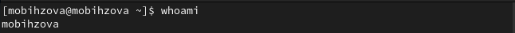

Работа команды whoami

## Выполнение лабораторной работы

Выведем на экран более подробную информацию, используя команду id (UID – id пользователя равный 1000. GID – id группы равный 1000) (рис. 2).

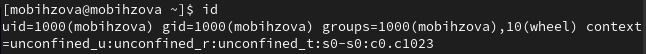

Работа команды id

## Выполнение лабораторной работы

Используем команду su для переключения к учётной записи root. При запросе пароля вводим пароль пользователя root. Наберём id (UID – id пользователя равный 0. GID – id группы равный 0) (рис. 3, рис. 4).

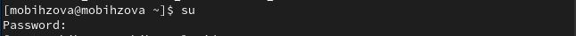

Работа команды su

## Выполнение лабораторной работы

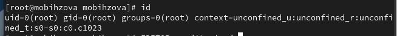

Работа команды id

## Выполнение лабораторной работы

После мы должны убедиться, что в открытом с помощью visudo файле присутствует строка %wheel ALL=(ALL) ALL (данная строка присутствует). (рис. 6).

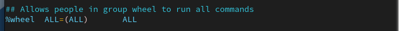

Проверка наличия строки

## Выполнение лабораторной работы

По закрытии файла создаём пользователя alice, входящего в группу wheel с помощью команды: useradd -G wheel alice (рис. 7).

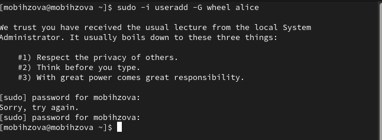

Создание пользователя alice

## Выполнение лабораторной работы

Нужно убедиться, что пользователь alice добавлен в группу wheel. Для этого введём команду id alice (Groups = 1001(alice),10(wheel)). (рис. 8).

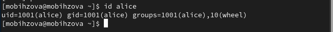

Информация о пользователе alice

## Выполнение лабораторной работы

Следующим шагом зададим пароль для пользователя alice, набрав passwd alice. Пароль требуется ввести дважды (рис. 9).

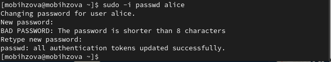

Создание пароля для пользователя alice

## Выполнение лабораторной работы

Переключаемся на учётную запись пользователя alice командой: su alice. (рис. 10).

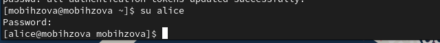

Смена пользователя

## Выполнение лабораторной работы

Создаём пользователя bob: sudo useradd bob (рис. 11).

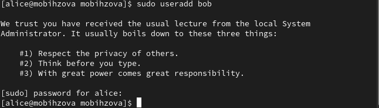

Создание пользователя bob

## Выполнение лабораторной работы

При запросе вводим пароль пользователя. Проверяем, что пользователь bob создан (id bob) и устанавливаем пароль для пользователя: sudo passwd bob (рис. 12).

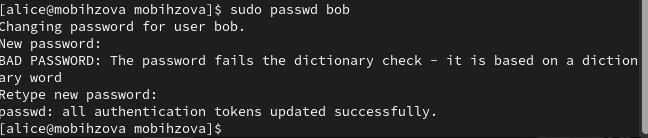

Создание пароля для пользователя bob

## Выполнение лабораторной работы

Посмотрим, в какие группы входит пользователь bob (рис. 13).

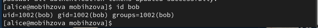

Информация о пользователе bob

## Выполнение лабораторной работы

Переключимся в терминале на учётную запись пользователя root. Откроем файл конфигурации /etc/login.defs для редактирования (рис. 14).

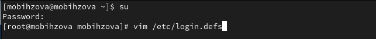

Смена пользователя. Открытие файла

## Выполнение лабораторной работы

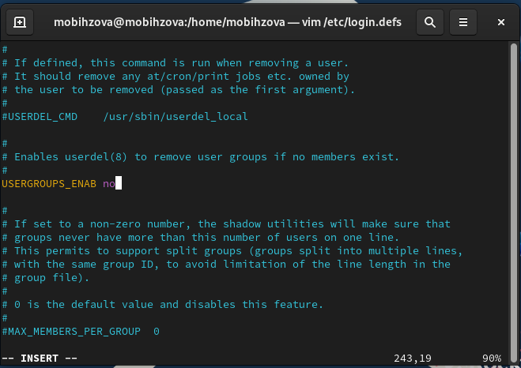

Изменение параметра USERGROUPS_ENAB и USERGROUPS_ENAB

## Выполнение лабораторной работы

После закрытия файла перейдём в каталог /etc/skel: cd /etc/skel. В этом каталоге создаём подкаталоги Pictures и Documents: mkdir Pictures Documents (это позволит добавить эти каталоги по умолчанию во все домашние каталоги пользователей). Выполняем проверку создания командой: ls (рис. 16).

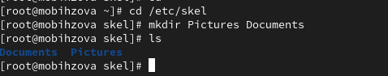

Открытие каталога /etc/skel и создание подкаталогов Pictures и Documents, проверка создания

## Выполнение лабораторной работы

Теперь нам нужно изменить содержимое файла .bashrc, добавив строку: export EDITOR=/usr/bin/vim (эта запись означает, что текстовый редактор vim будет установлен по умолчанию для инструментов, которые нуждаются в изменении текстовых файлов) (рис. 17).

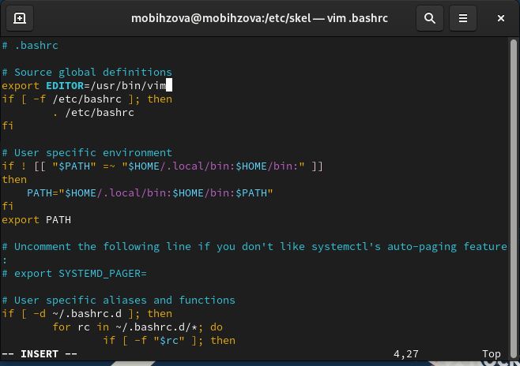

Добавление строки: export EDITOR=/usr/bin/vim

## Выполнение лабораторной работы

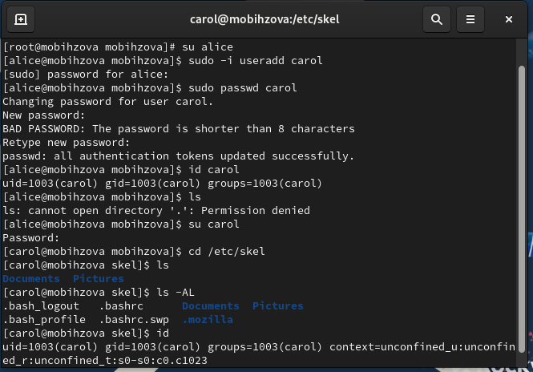

Создание пользователя carol и установка пароля. Просмотр информации о пользователе carol и проверка наличия каталогов.

## Выполнение лабораторной работы

Просмотрим информацию о пользователе carol (рис. 19)

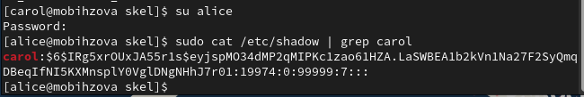

Информация о пароле пользователя carol

## Выполнение лабораторной работы

Изменим свойства пароля пользователя carol следующим образом: passwd -n 30 -w 3 -x 90 carol (рис. 20).

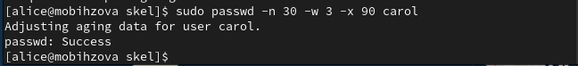

Изменение свойства пароля пользователя carol

## Выполнение лабораторной работы

Убедимся в изменении в строке с данными о пароле пользователя carol в файле /etc/shadow (рис. 21).

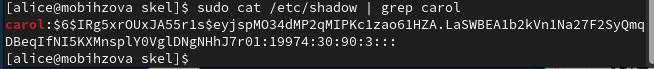

Информация о пароле пользователя carol

## Выполнение лабораторной работы

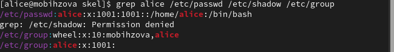

Индентификатор alice

## Выполнение лабораторной работы

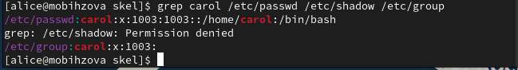

Индентификатор carol

## Выполнение лабораторной работы

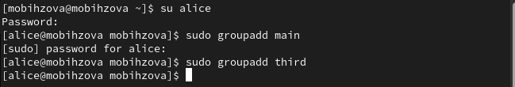

Создание групп

## Выполнение лабораторной работы

Затем используем usermod для добавления пользователей alice и bob в группу main, а carol, dan, dave и david - в группу third (рис. 25).

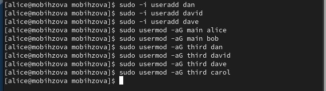

Добавление пользователей в группы

## Выполнение лабораторной работы

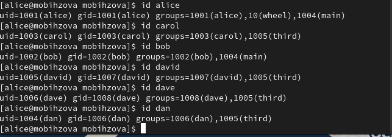

Определение, участниками каких групп являются созданные пользователи.

## Выводы

В ходе выполнения лабораторной работы были получены представление о работе с учётными записями пользователей и группами пользователей в операционной системе типа Linux.

## Список литературы

1. Робачевский А., Немнюгин С., Стесик О. Операционная система UNIX. — 2-е изд. — БХВ-Петербург, 2010.
2. Колисниченко Д. Н. Самоучитель системного администратора Linux. — СПб. : БХВ-Петербург, 2011. — (Системный администратор).
3. Таненбаум Э., Бос Х. Современные операционные системы. — 4-е изд. — СПб. : Питер, 2015. — (Классика Computer Science).
4. Neil N. J. Learning CentOS: A Beginners Guide to Learning Linux. — CreateSpace Independent Publishing Platform, 2016.
5. Unix и Linux: руководство системного администратора / Э. Немет, Г. Снайдер, Т.Хейн, Б. Уэйли, Д. Макни. — 5-е изд. — СПб. : ООО «Диалектика», 2020.